# Analisis 2

Cristopher Valenzuela

28 de febrero de 2022

Un estudio contiene dos medidas de los anillos de crecimiento en las escamas de salmones de Alaska y de Canadá. Los datos se pueden obtener del archivo salmon.txt. Guardar este archivo en R como un data.frame de nombre salmon con la función read.table. Estos datos también se pueden hallar en el dataframe salmon del paquete rrcov.

1. Realizar una estadística descriptiva univariante y multivariante según el factor SalmonOrigin.

```r
salmon <- read.table("salmon.txt", header=TRUE, stringsAsFactors = TRUE)
str(salmon)
```

```
## 'data.frame':    100 obs. of  3 variables:
##  $ Freshwater  : int  108 131 105 86 99 87 94 117 79 99 ...
##  $ Marine      : int  368 355 469 506 402 423 440 489 432 403 ...
##  $ SalmonOrigin: Factor w/ 2 levels "Alaska","Canada": 1 1 1 1 1 1 1 1 1 1 ...
```

```r
attach(salmon)
summary(salmon)
```

```
##    Freshwater        Marine      SalmonOrigin
##  Min.   : 53.0   Min.   :301.0   Alaska:50
##  1st Qu.: 99.0   1st Qu.:367.0   Canada:50
##  Median :117.5   Median :396.5
##  Mean   :117.9   Mean   :398.1
##  3rd Qu.:140.0   3rd Qu.:428.2
##  Max.   :179.0   Max.   :511.0
```

```r
salmon.num <- salmon[, 1:2]
sapply(salmon.num, function(x) tapply(x, SalmonOrigin, mean))
```

```
##        Freshwater Marine
## Alaska      98.38 429.66
## Canada     137.46 366.62
```

```r
sapply(salmon.num, function(x) tapply(x, SalmonOrigin, sd))
```

```
##        Freshwater   Marine
## Alaska   16.14335 37.40436
## Canada   18.05797 29.88747
```

```r
var(salmon.num)
```

```
##            Freshwater    Marine
## Freshwater   676.0541 -649.1402
## Marine      -649.1402 2138.1418
```

```r
cor(salmon.num)
```

```
##            Freshwater     Marine
## Freshwater  1.0000000 -0.5399201
## Marine     -0.5399201  1.0000000
```

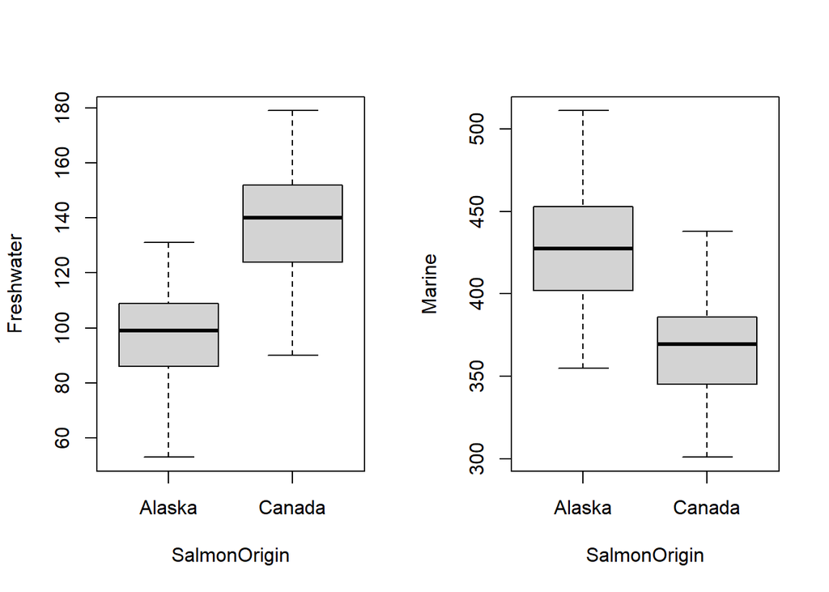

```r
oldpar <- par(mfrow=c(1,2))
boxplot(Freshwater ~ SalmonOrigin)
boxplot(Marine ~ SalmonOrigin)
```

Se realizan graficos de dispersion

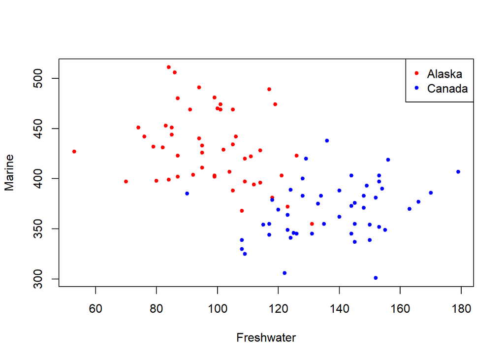

```r
par(oldpar)

library(ggplot2)
plot(salmon.num, col=ifelse(SalmonOrigin=="Alaska", "red", "blue"), pch=20)
legend("topright", levels(SalmonOrigin), col=c("red","blue"), pch=20)
```

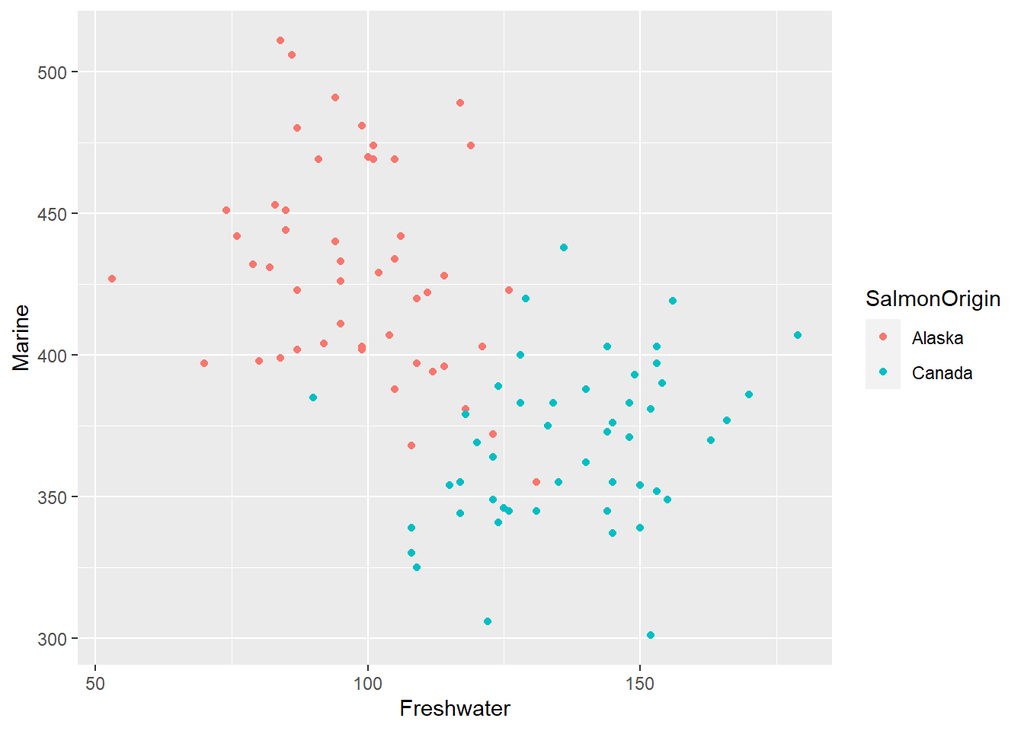

```r
ggplot(salmon, aes(x=Freshwater, y=Marine, color=SalmonOrigin)) +
  geom_point()
```

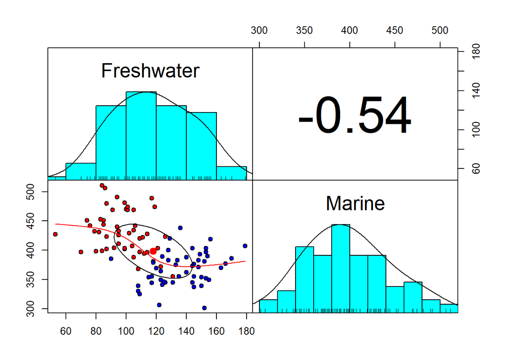

```r
library(psych)
pairs.panels(salmon.num,
             gap = 0,
             bg = c("red", "blue")[SalmonOrigin],
             pch = 21)
```

2. Realizar un análisis discriminante lineal

```r
library(MASS)
fit.cv <- lda(SalmonOrigin ~ Freshwater + Marine, data=salmon, CV=TRUE)
# Assess the accuracy of the prediction
# percent correct for each category of G
ct <- table(salmon$SalmonOrigin, fit.cv$class)
diag(prop.table(ct, 1))
```

```
## Alaska Canada
##   0.88   0.98
```

```r
# total percent correct
sum(diag(prop.table(ct)))
```

```
## [1] 0.93
```

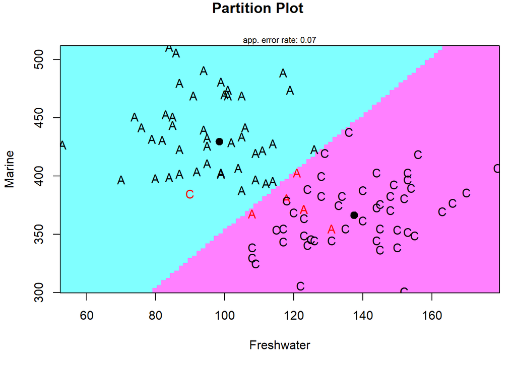

```r
library(klaR)
partimat(SalmonOrigin ~ Marine + Freshwater, data=salmon, method="lda")
```

Los histogramas para los valores de la primera función discriminante son:

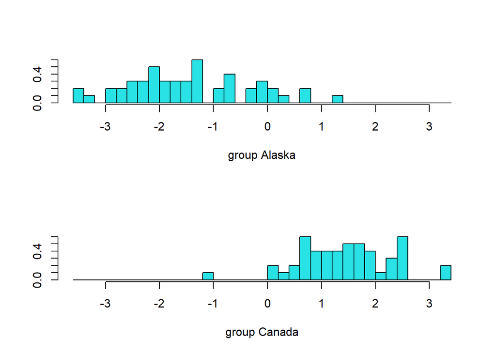

```r
linear <- lda(SalmonOrigin ~ ., salmon)
p <- predict(linear)
ldahist(data = p$x[,1], g = SalmonOrigin)
```

Clasificamos una nueva observacion

```r
fit <- lda(SalmonOrigin ~ Freshwater + Marine, data=salmon)
predict(fit, data.frame(Freshwater=120,Marine=380))$class
```

```
## [1] Canada
## Levels: Alaska Canada
```

3. Estudiar la normalidad multivariante de las dos poblaciones con el test de Mardia que se basa en la asimetría y la kurtosis multivariante.

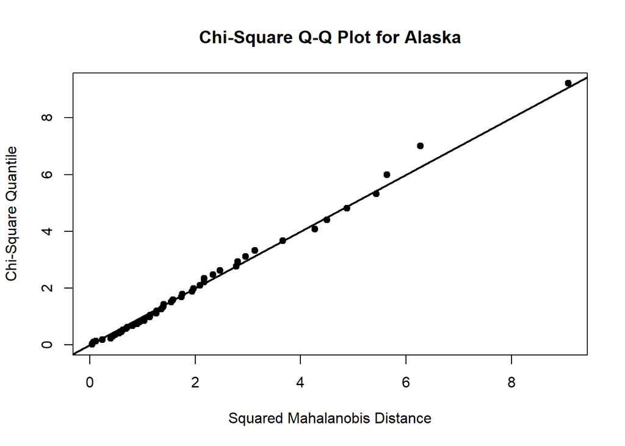

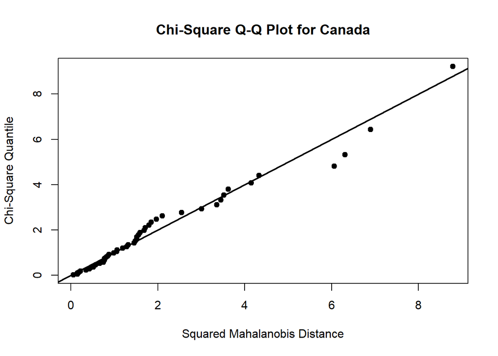

```
## $multivariateNormality
## $multivariateNormality$Alaska
##              Test          Statistic           p value Result
## 1 Mardia Skewness   6.67860033109113 0.153879248834123    YES
## 2 Mardia Kurtosis -0.543809625889093 0.586572484145819    YES
## 3             MVN               <NA>              <NA>    YES
##
## $multivariateNormality$Canada
##              Test           Statistic           p value Result
## 1 Mardia Skewness   0.782204925537997 0.940817697109154    YES
## 2 Mardia Kurtosis -0.0288686753407277 0.976969328661072    YES
## 3             MVN                <NA>              <NA>    YES
##
##
## $univariateNormality
## $univariateNormality$Alaska
##           Test   Variable Statistic   p value Normality
## 1 Shapiro-Wilk Freshwater    0.9874    0.8664    YES
## 2 Shapiro-Wilk   Marine      0.9778    0.4639    YES
##
## $univariateNormality$Canada
##           Test   Variable Statistic   p value Normality
## 1 Shapiro-Wilk Freshwater    0.9816    0.6197    YES
## 2 Shapiro-Wilk   Marine      0.9847    0.7574    YES
##
##
## $Descriptives
## $Descriptives$Alaska
##             n   Mean  Std.Dev Median Min Max   25th  75th       Skew   Kurtosis
## Freshwater 50  98.38 16.14335   99.0  53 131  86.25 109.0 -0.2117158 -0.2055946
## Marine     50 429.66 37.40436  427.5 355 511 402.00 452.5  0.2277552 -0.7279458
##
## $Descriptives$Canada
##             n   Mean  Std.Dev Median Min Max   25th   75th        Skew
## Freshwater 50 137.46 18.05797  140.0  90 179 124.00 151.50 -0.17056928
## Marine     50 366.62 29.88747  369.5 301 438 345.25 385.75 -0.07051701
##              Kurtosis
## Freshwater -0.3209330
## Marine     -0.2212072
```

```r
library(MVN)
mvn(salmon,"SalmonOrigin", mvnTest = "mardia",
                                     univariateTest = "SW",
                                     univariatePlot = "qq",
                                     multivariatePlot = "qq")
```

4. Con el mismo fin que en el apartado anterior se puede utilizar la función mardia() del paquete psych, sin embargo los resultados son distintos ya que esta función utiliza la matriz de covarianzas insesgada. Comprobar que la función mvn() también se puede ajustar para que los cálculos coincidan con los de la función mardia().

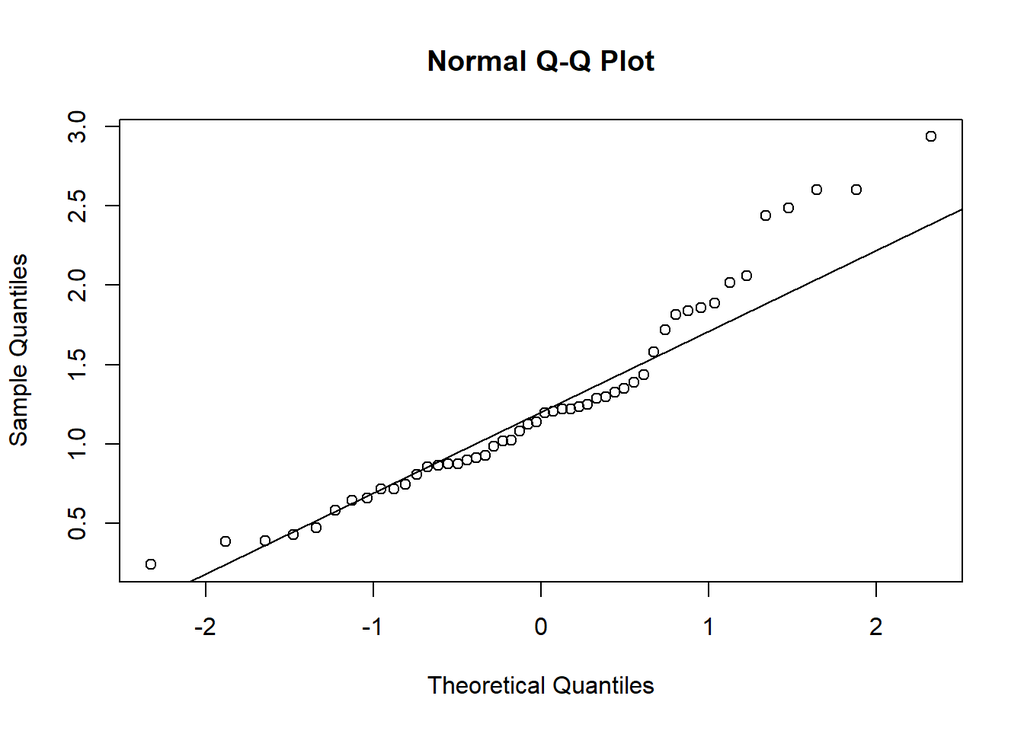

```
## Call: mardia(x = salmon[SalmonOrigin == "Canada", -3])
##
## Mardia tests of multivariate skew and kurtosis
## Use describe(x) the to get univariate tests
## n.obs = 50   num.vars =  2
## b1p =  0.09   skew =  0.74  with probability  <=  1.9
##  small sample skew =  0.81  with probability <=  1.9
## b2p =  7.65   kurtosis =  -0.31  with probability <=  0.76
```

```r
mardia(salmon[SalmonOrigin=="Canada",-3])
```

Comprobamos que con la función mvn() y la matriz de covarianzas insesgada se obtiene el mismo resultado.

```r
mvn(salmon,"SalmonOrigin", mvnTest = "mardia",
                             covariance = FALSE)$multivariateNormality
```

```
## $Alaska
##              Test          Statistic           p value Result
## 1 Mardia Skewness   6.28584520282033 0.178793973822649    YES
## 2 Mardia Kurtosis -0.802289050053757 0.422385774982733    YES
## 3             MVN               <NA>              <NA>    YES
##
## $Canada
##              Test          Statistic           p value Result
## 1 Mardia Skewness  0.736205018276957 0.946790193264509    YES
## 2 Mardia Kurtosis -0.307739761147106 0.758280361953134    YES
## 3             MVN               <NA>              <NA>    YES
```

5. Comparar las matrices de covarianzas de las dos poblaciones con el test de la razón de verosimilitudes.

Para comparar las matrices de covarianzas de los 2 grupos utilizaremos el test de la razón de verosimilitudes.

En primer lugar calculamos el número de casos para cada nivel:

```r
table(SalmonOrigin)
```

```
## SalmonOrigin
## Alaska Canada
##     50     50
```

Se trata de un experimento balanceado con 50 réplicas por nivel.

Para utilizar el test de la razón de verosimilitudes es preciso utilizar las estimaciones máximo-verosímiles de las matrices de covarianzas:

```r
(S1 <- cov(salmon[SalmonOrigin=="Alaska", 1:2]))
```

```
##            Freshwater    Marine
## Freshwater   260.6078 -188.0927
## Marine      -188.0927 1399.0861
```

```r
(S2 <- cov(salmon[SalmonOrigin=="Canada", 1:2]))
```

```
##            Freshwater   Marine
## Freshwater   326.0902 133.5049
## Marine       133.5049 893.2608
```

```r
S1 <- 49*S1/50; S2 <- 49*S2/50
S1
```

```
##            Freshwater    Marine
## Freshwater   255.3956 -184.3308
## Marine      -184.3308 1371.1044
```

Observamos que unas pocas observaciones hacen que el signo de la covarianza sea distinto en las dos poblaciones.

Así, la matriz de covarianzas común es

```r
S <- (50*S1 + 50*S2)/100
S
```

```
##            Freshwater   Marine
## Freshwater    287.482  -26.748
## Marine        -26.748 1123.250
```

y el estadístico (este estadístico puede ser sesgado y convendría aplicar la corrección de Box)

```r
llr <- 100*log(det(S)) - (50*log(det(S1)) + 50*log(det(S2)))
```

cuyo p-valor es

```r
s <- 2 # número de niveles
p <- 2 # número de variables
pchisq(llr, df= (s-1)*p*(p+1)/2, lower.tail=FALSE)
```

```
## [1] 0.01088541
```

de modo que hay motivo para rechazar la igualdad de las matrices de covarianzas.

El mismo resultado se obtiene con el test M de Box.

```r
library(biotools)
boxM(salmon.num, SalmonOrigin)
```

```
##
##  Box's M-test for Homogeneity of Covariance Matrices
##
## data:  salmon.num
## Chi-Sq (approx.) = 10.696, df = 3, p-value = 0.01349
```

6. Como los dos tests del apartado anterior son muy sensibles a la no normalidad de los datos y tienden a rechazar la igualdad de covarianzas, realizar el test multivariante de Levene.

En primer lugar estandarizamos las variables con la función scale() y calculamos el vector de medianas para cada grupo.

```r
matestandar <- scale(salmon.num)
mat.Alaska <- matestandar[SalmonOrigin == "Alaska",]
mat.Canada <- matestandar[SalmonOrigin == "Canada",]
medianas.Alaska <- apply(mat.Alaska, 2, median)
medianas.Canada <- apply(mat.Canada, 2, median)
```

Ahora preparamos los datos restando las medianas y calculando los valores absolutos.

```r
matabsdev.Alaska <- abs(sweep(mat.Alaska,2,medianas.Alaska,"-"))
matabsdev.Canada <- abs(sweep(mat.Canada,2,medianas.Canada,"-"))
matabsdev.all <- rbind(matabsdev.Alaska,matabsdev.Canada)
matabsdev.all <- data.frame(SalmonOrigin, matabsdev.all)
```

Finalmente realizamos el test T2 de Hotelling para comparar las dos poblaciones.

```r
library(Hotelling)
fit <- hotelling.test(matabsdev.Alaska,matabsdev.Canada)
fit
```

```
## Test stat:  3.327
## Numerator df:  2
## Denominator df:  97
## P-value:  0.1981
```

Con este test, menos sensible que los dos anteriores, aceptamos la igualdad de las variabilidades de las dos problaciones.

7. Comparar la variabilidad de los dos grupos con la generalización multivariante del test de Levene llamada test de Van Valen.

Compararemos la variabilidad de los dos grupos con una generalización multivariante del test de Levene llamada test de Van Valen.

Para ello seguiremos el algoritmo paso a paso. En el apartado anterior ya estandarizamos las variables y hemos calculado el vector de medianas para cada grupo.

```r
matabsdev.all <- rbind(matabsdev.Alaska,matabsdev.Canada)
matabsdev.all <- data.frame(SalmonOrigin, matabsdev.all)

#calculamos distancias euclideas

norma.euclidea <- function(x) sqrt(sum(x^2))
distancias <- data.frame(SalmonOrigin, dist=apply(matabsdev.all[,-1],1,norma.euclidea))

# finalmente hacemos el test de comparación de los dos grupos.

dist_1 <- distancias$dist[SalmonOrigin=="Alaska"]
dist_2 <- distancias$dist[SalmonOrigin=="Canada"]
t.test(dist_1, dist_2, var.equal=T, data=distancias)
```

```
##
##  Two Sample t-test
##
## data:  dist_1 and dist_2
## t = 0.67356, df = 98, p-value = 0.5022
## alternative hypothesis: true difference in means is not equal to 0
## 95 percent confidence interval:
##  -0.1166781  0.2365791
## sample estimates:
## mean of x mean of y
## 0.9038596 0.8439091
```

También con este test aceptamos la igualdad de variabilidades de las dos poblaciones.

También se puede utilizar un test no paramétrico en lugar del test t de Student.

```r
wilcox.test(dist_1,dist_2, data=distancias)
```

```
##
##  Wilcoxon rank sum test with continuity correction
##
## data:  dist_1 and dist_2
## W = 1370, p-value = 0.41
## alternative hypothesis: true location shift is not equal to 0
```

8. En el caso de poblaciones normales con diferentes matrices de covarianzas se clasificará cada observación en el grupo con máxima probabilidad a posteriori, pero entonces las funciones discriminantes no son lineales, ya que tienen un término de segundo grado.

```r
salmon.qda <- qda(SalmonOrigin ~ ., data=salmon)
clq <- predict(salmon.qda, salmon[,-1])$class
table(SalmonOrigin, clq)
```

```
##             clq
## SalmonOrigin Alaska Canada
##       Alaska     45      5
##       Canada      2     48
```

1. Calcular el número de parámetros que hay que estimar en la discriminación lineal y en la cuadrática.

```r
2*2+2*(2+1)/2
```

```
## [1] 7
```

Se obtuvieron que necesitamos calcular 7 parametros.Ahora, calculamos el numero de parametros para la discriminacion cuadratica.

```r
2*(2+2*(2+1)/2)
```

```
## [1] 10
```

10. Calcular los errores de clasificación con ambas reglas utilizando validación cruzada.

Para calcular la tasa de error por validación cruzada se utiliza la opción CV = TRUE en las funciones de R.

```r
1 - sum(fit.cv$class == SalmonOrigin)/100
```

```
## [1] 0.07
```

```r
salmon.qda.cv <- qda(SalmonOrigin ~ ., data=salmon, CV=TRUE)
1 - sum(salmon.qda.cv$class == SalmonOrigin)/100
```

```
## [1] 0.08
```

Dado que el discriminador lineal con 2 variables consigue clasificar bien casi todos los datos, lo más aconsejable en este caso es desestimar las opciones más complejas. Cuantos menos parámetros haya que estimar, más robusto resulta el discriminador y más fácil su interpretación.

Vamos a utilizar unos datos del Old Faithful, uno de los géiseres más conocidos del Parque nacional de Yellowstone, en el estado de Wyoming de los Estados Unidos. Para obtener este conjunto de datos en R simplemente hay que ejecutar la instrucción faithful. También hay un archivo de ayuda que se ve con la instrucción ?faithful.

1. Como un estudio preliminar, realizar un análisis de conglomerados jerárquico con las distancias euclídeas y el método de Ward.

```r
data(faithful)
str(faithful)
```

```
## 'data.frame':    272 obs. of  2 variables:
##  $ eruptions: num  3.6 1.8 3.33 2.28 4.53 ...
##  $ waiting  : num  79 54 74 62 85 55 88 85 51 85 ...
```

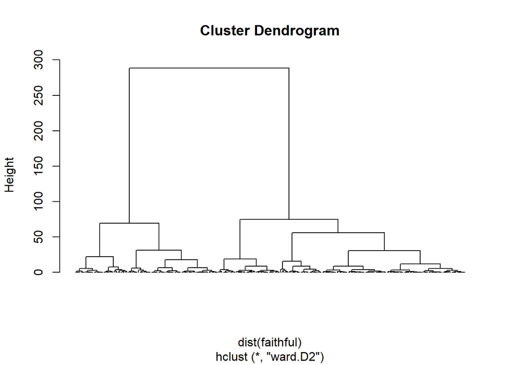

```r
hc <- hclust(dist(faithful), method = "ward.D2")
plot(hc, labels=F, hang=-1)
```

El dendograma sugiere 2 conclomerados.

2. Cuando se procede a un análisis k-means, estamos interesados en saber hasta qué punto los conglomerados se empaquetan estrechamente, eso nos puede ayudar a determinar el valor apropiado de k. Vamos a utilizar la suma de cuadrados dentro del grupo (within group sum of squares).

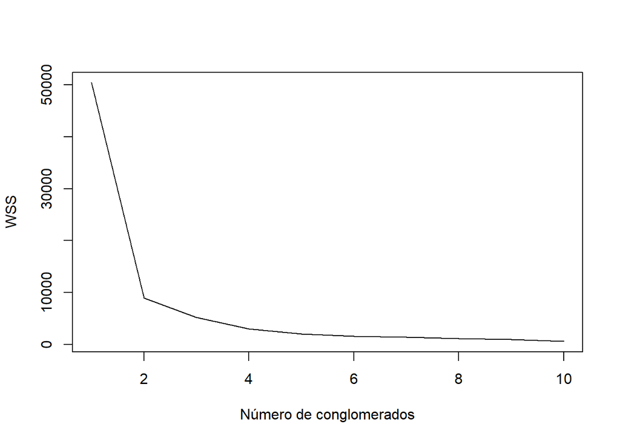

```r
WSS <- rep(0,10)
n <- nrow(faithful)
WSS[1] <- (n-1)*sum(apply(faithful,2,var))

#Se trata de calcular la varianza para las dos columnas o variables del data.frame faithful, sumarlas y multiplicar por el número de observaciones menos 1.

set.seed(123)
for (k in 2:10) WSS[k] <- kmeans(faithful, k)$tot.withinss

#El gráfico de WSS como función de k es:
plot(1:10,WSS, xlab="Número de conglomerados", ylab="WSS", type="l")
```

Dos parece ser suficiente, como maximo 5.

3. Realizar un particionado alrededor de los k-medoides.

```r
library(cluster)
si.avg <- rep(0,6)
for (k in 2:7) {
pr <- pam(faithful, k)
si.avg[k-1] <- summary(silhouette(pr))$avg.width
}
si.avg
```

```
## [1] 0.7240549 0.5818580 0.5523999 0.5331805 0.5369056 0.5344719
```

En este caso el mejor número de conglomerados es 2.

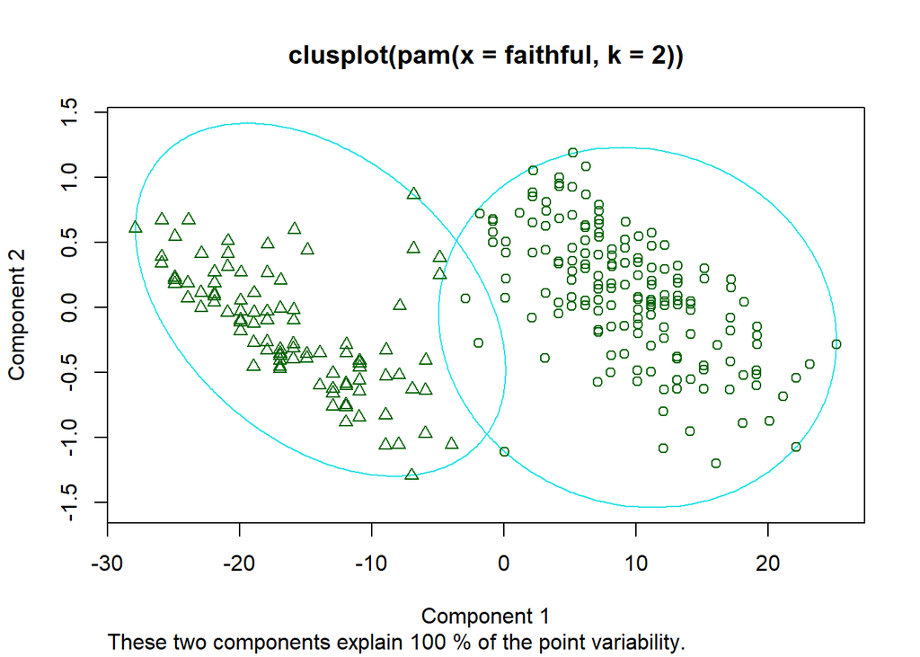

```r
pam2 <- pam(faithful, 2)
si <- silhouette(pam2)
# plot(si, col = c("red", "green"))
clusplot(pam2)
```